# 03_Nrest_cancer_Classification_using_Neural_network

```python
import numpy as np
import pandas as pd
import matplotlib.pyplot as plt

from sklearn.model_selection import train_test_split
import sklearn.datasets
```

```python
Can_data = sklearn.datasets.load_breast_cancer()
```

```python
print(Can_data)
```

[output not shown]

```python
# create dataframe
df = pd.DataFrame(Can_data.data, columns=Can_data.feature_names)

# check
print(df.head())
```

```
   mean radius  mean texture  mean perimeter  mean area  mean smoothness  \
0        17.99         10.38          122.80     1001.0          0.11840
1        20.57         17.77          132.90     1326.0          0.08474
2        19.69         21.25          130.00     1203.0          0.10960
3        11.42         20.38           77.58      386.1          0.14250
4        20.29         14.34          135.10     1297.0          0.10030

   mean compactness  mean concavity  mean concave points  mean symmetry  \
0           0.27760          0.3001              0.14710         0.2419
1           0.07864          0.0869              0.07017         0.1812
2           0.15990          0.1974              0.12790         0.2069
3           0.28390          0.2414              0.10520         0.2597
4           0.13280          0.1980              0.10430         0.1809

   mean fractal dimension  ...  worst radius  worst texture  worst perimeter  \
```

[output cut: 21 more lines]

```python
df.columns
```

```
Index(['mean radius', 'mean texture', 'mean perimeter', 'mean area',
       'mean smoothness', 'mean compactness', 'mean concavity',
       'mean concave points', 'mean symmetry', 'mean fractal dimension',
       'radius error', 'texture error', 'perimeter error', 'area error',
       'smoothness error', 'compactness error', 'concavity error',
       'concave points error', 'symmetry error', 'fractal dimension error',
       'worst radius', 'worst texture', 'worst perimeter', 'worst area',
       'worst smoothness', 'worst compactness', 'worst concavity',
       'worst concave points', 'worst symmetry', 'worst fractal dimension'],
      dtype='object')
```

```python
df.shape
```

```
(569, 30)
```

```python
# Add target col
df["label"] = Can_data.target
```

```python
df.tail()
```

|  | mean radius | mean texture | mean perimeter | mean area | mean smoothness | mean compactness | mean concavity | mean concave points | mean symmetry | mean fractal dimension | ... | worst texture | worst perimeter | worst area | worst smoothness | worst compactness | worst concavity | worst concave points | worst symmetry | worst fractal dimension | label |
| --- | --- | --- | --- | --- | --- | --- | --- | --- | --- | --- | --- | --- | --- | --- | --- | --- | --- | --- | --- | --- | --- |
| 564 | 21.56 | 22.39 | 142.00 | 1479.0 | 0.11100 | 0.11590 | 0.24390 | 0.13890 | 0.1726 | 0.05623 | ... | 26.40 | 166.10 | 2027.0 | 0.14100 | 0.21130 | 0.4107 | 0.2216 | 0.2060 | 0.07115 | 0 |
| 565 | 20.13 | 28.25 | 131.20 | 1261.0 | 0.09780 | 0.10340 | 0.14400 | 0.09791 | 0.1752 | 0.05533 | ... | 38.25 | 155.00 | 1731.0 | 0.11660 | 0.19220 | 0.3215 | 0.1628 | 0.2572 | 0.06637 | 0 |
| 566 | 16.60 | 28.08 | 108.30 | 858.1 | 0.08455 | 0.10230 | 0.09251 | 0.05302 | 0.1590 | 0.05648 | ... | 34.12 | 126.70 | 1124.0 | 0.11390 | 0.30940 | 0.3403 | 0.1418 | 0.2218 | 0.07820 | 0 |
| 567 | 20.60 | 29.33 | 140.10 | 1265.0 | 0.11780 | 0.27700 | 0.35140 | 0.15200 | 0.2397 | 0.07016 | ... | 39.42 | 184.60 | 1821.0 | 0.16500 | 0.86810 | 0.9387 | 0.2650 | 0.4087 | 0.12400 | 0 |
| 568 | 7.76 | 24.54 | 47.92 | 181.0 | 0.05263 | 0.04362 | 0.00000 | 0.00000 | 0.1587 | 0.05884 | ... | 30.37 | 59.16 | 268.6 | 0.08996 | 0.06444 | 0.0000 | 0.0000 | 0.2871 | 0.07039 | 1 |

5 rows × 31 columns

```python
print(df.shape)
```

```
(569, 31)
```

```python
df.info()
```

```
<class 'pandas.core.frame.DataFrame'>
RangeIndex: 569 entries, 0 to 568
Data columns (total 31 columns):
 #   Column                   Non-Null Count  Dtype
---  ------                   --------------  -----
 0   mean radius              569 non-null    float64
 1   mean texture             569 non-null    float64
 2   mean perimeter           569 non-null    float64
 3   mean area                569 non-null    float64
 4   mean smoothness          569 non-null    float64
 5   mean compactness         569 non-null    float64
 6   mean concavity           569 non-null    float64
 7   mean concave points      569 non-null    float64
 8   mean symmetry            569 non-null    float64
 9   mean fractal dimension   569 non-null    float64
```

[output cut: 23 more lines]

```python
df.isnull().sum() # Checking the missing values.
```

```
mean radius                0
mean texture               0
mean perimeter             0
mean area                  0
mean smoothness            0
mean compactness           0
mean concavity             0
mean concave points        0
mean symmetry              0
mean fractal dimension     0
radius error               0
texture error              0
perimeter error            0
area error                 0
smoothness error           0
compactness error          0
concavity error            0
concave points error       0
symmetry error             0
fractal dimension error    0
worst radius               0
worst texture              0
worst perimeter            0
worst area                 0
worst smoothness           0
worst compactness          0
worst concavity            0
worst concave points       0
worst symmetry             0
worst fractal dimension    0
label                      0
dtype: int64
```

```python
df.describe()
```

|  | mean radius | mean texture | mean perimeter | mean area | mean smoothness | mean compactness | mean concavity | mean concave points | mean symmetry | mean fractal dimension | ... | worst texture | worst perimeter | worst area | worst smoothness | worst compactness | worst concavity | worst concave points | worst symmetry | worst fractal dimension | label |
| --- | --- | --- | --- | --- | --- | --- | --- | --- | --- | --- | --- | --- | --- | --- | --- | --- | --- | --- | --- | --- | --- |
| count | 569.000000 | 569.000000 | 569.000000 | 569.000000 | 569.000000 | 569.000000 | 569.000000 | 569.000000 | 569.000000 | 569.000000 | ... | 569.000000 | 569.000000 | 569.000000 | 569.000000 | 569.000000 | 569.000000 | 569.000000 | 569.000000 | 569.000000 | 569.000000 |
| mean | 14.127292 | 19.289649 | 91.969033 | 654.889104 | 0.096360 | 0.104341 | 0.088799 | 0.048919 | 0.181162 | 0.062798 | ... | 25.677223 | 107.261213 | 880.583128 | 0.132369 | 0.254265 | 0.272188 | 0.114606 | 0.290076 | 0.083946 | 0.627417 |
| std | 3.524049 | 4.301036 | 24.298981 | 351.914129 | 0.014064 | 0.052813 | 0.079720 | 0.038803 | 0.027414 | 0.007060 | ... | 6.146258 | 33.602542 | 569.356993 | 0.022832 | 0.157336 | 0.208624 | 0.065732 | 0.061867 | 0.018061 | 0.483918 |
| min | 6.981000 | 9.710000 | 43.790000 | 143.500000 | 0.052630 | 0.019380 | 0.000000 | 0.000000 | 0.106000 | 0.049960 | ... | 12.020000 | 50.410000 | 185.200000 | 0.071170 | 0.027290 | 0.000000 | 0.000000 | 0.156500 | 0.055040 | 0.000000 |
| 25% | 11.700000 | 16.170000 | 75.170000 | 420.300000 | 0.086370 | 0.064920 | 0.029560 | 0.020310 | 0.161900 | 0.057700 | ... | 21.080000 | 84.110000 | 515.300000 | 0.116600 | 0.147200 | 0.114500 | 0.064930 | 0.250400 | 0.071460 | 0.000000 |
| 50% | 13.370000 | 18.840000 | 86.240000 | 551.100000 | 0.095870 | 0.092630 | 0.061540 | 0.033500 | 0.179200 | 0.061540 | ... | 25.410000 | 97.660000 | 686.500000 | 0.131300 | 0.211900 | 0.226700 | 0.099930 | 0.282200 | 0.080040 | 1.000000 |
| 75% | 15.780000 | 21.800000 | 104.100000 | 782.700000 | 0.105300 | 0.130400 | 0.130700 | 0.074000 | 0.195700 | 0.066120 | ... | 29.720000 | 125.400000 | 1084.000000 | 0.146000 | 0.339100 | 0.382900 | 0.161400 | 0.317900 | 0.092080 | 1.000000 |
| max | 28.110000 | 39.280000 | 188.500000 | 2501.000000 | 0.163400 | 0.345400 | 0.426800 | 0.201200 | 0.304000 | 0.097440 | ... | 49.540000 | 251.200000 | 4254.000000 | 0.222600 | 1.058000 | 1.252000 | 0.291000 | 0.663800 | 0.207500 | 1.000000 |

8 rows × 31 columns

```python
df["label"].value_counts() # check balanced or imbalanced.
```

```
label
1    357
0    212
Name: count, dtype: int64
```

```python
df.groupby("label").mean()
```

| label | mean radius | mean texture | mean perimeter | mean area | mean smoothness | mean compactness | mean concavity | mean concave points | mean symmetry | mean fractal dimension | ... | worst radius | worst texture | worst perimeter | worst area | worst smoothness | worst compactness | worst concavity | worst concave points | worst symmetry | worst fractal dimension |
| --- | --- | --- | --- | --- | --- | --- | --- | --- | --- | --- | --- | --- | --- | --- | --- | --- | --- | --- | --- | --- | --- |
| 0 | 17.462830 | 21.604906 | 115.365377 | 978.376415 | 0.102898 | 0.145188 | 0.160775 | 0.087990 | 0.192909 | 0.062680 | ... | 21.134811 | 29.318208 | 141.370330 | 1422.286321 | 0.144845 | 0.374824 | 0.450606 | 0.182237 | 0.323468 | 0.091530 |
| 1 | 12.146524 | 17.914762 | 78.075406 | 462.790196 | 0.092478 | 0.080085 | 0.046058 | 0.025717 | 0.174186 | 0.062867 | ... | 13.379801 | 23.515070 | 87.005938 | 558.899440 | 0.124959 | 0.182673 | 0.166238 | 0.074444 | 0.270246 | 0.079442 |

2 rows × 30 columns

```python
X = df.drop(columns="label", axis = 1)
Y= df["label"]
```

```python
print(X)
```

```
     mean radius  mean texture  mean perimeter  mean area  mean smoothness  \
0          17.99         10.38          122.80     1001.0          0.11840
1          20.57         17.77          132.90     1326.0          0.08474
2          19.69         21.25          130.00     1203.0          0.10960
3          11.42         20.38           77.58      386.1          0.14250
4          20.29         14.34          135.10     1297.0          0.10030
..           ...           ...             ...        ...              ...
564        21.56         22.39          142.00     1479.0          0.11100
565        20.13         28.25          131.20     1261.0          0.09780
566        16.60         28.08          108.30      858.1          0.08455
567        20.60         29.33          140.10     1265.0          0.11780
568         7.76         24.54           47.92      181.0          0.05263

     mean compactness  mean concavity  mean concave points  mean symmetry  \
0             0.27760         0.30010              0.14710         0.2419
```

[output cut: 64 more lines]

```python
print(Y)
```

```
0      0
1      0
2      0
3      0
4      0
      ..
564    0
565    0
566    0
567    0
568    1
Name: label, Length: 569, dtype: int64
```

#### Train Test Split

```python
X_train, X_test, Y_train, Y_test = train_test_split(X,Y, test_size=0.2, random_state=2)
```

```python
print(X.shape, X_train.shape, X_test.shape)
```

```
(569, 30) (455, 30) (114, 30)
```

#### Standardize the data:

```python
from sklearn.preprocessing import StandardScaler
```

```python
scaler = StandardScaler()
```

```python
X_train_standard = scaler.fit_transform(X_train)
# transform--->
#
X_test_standard = scaler.transform(X_test)
```

```python
print(X_train_standard)
```

```
[[-0.01330339  1.7757658  -0.01491962 ... -0.13236958 -1.08014517
  -0.03527943]
 [-0.8448276  -0.6284278  -0.87702746 ... -1.11552632 -0.85773964
  -0.72098905]
 [ 1.44755936  0.71180168  1.47428816 ...  0.87583964  0.4967602
   0.46321706]
 ...
 [-0.46608541 -1.49375484 -0.53234924 ... -1.32388956 -1.02997851
  -0.75145272]
 [-0.50025764 -1.62161319 -0.527814   ... -0.0987626   0.35796577
  -0.43906159]
 [ 0.96060511  1.21181916  1.00427242 ...  0.8956983  -1.23064515
   0.50697397]]
```

#### Neural network

input -->Hidden --> op layers

```python
# importing tensorflow and keras
import tensorflow as tf
tf.random.set_seed(3)
from tensorflow import keras
```

- **TensorFlow**: A deep learning library developed by Google.
- **Keras**: A high-level API (wrapper) built on top of TensorFlow.
- **Random seed**: When training neural networks in TensorFlow + Keras, certain weights are initialized randomly. Setting a random seed ensures reproducibility of results.

```python
# Setting up the layers:
model = keras.Sequential([
    keras.layers.Flatten(input_shape=(30,)),       # Input Layer (30 features → 1D array)
    keras.layers.Dense(20, activation='relu'),     # Hidden Layer with 20 neurons and ReLU activation
    keras.layers.Dense(2, activation='sigmoid')    # Output Layer with 2 neurons and Sigmoid activation
])
```

### Model Architecture

- **Flatten Layer**:  
  Converts the input feature matrix into a 1D array.  
  Since we have 30 features, this layer ensures each feature is passed to a corresponding neuron in the input layer.
- **Dense Layer (Hidden Layer)**:
  - Contains 20 neurons.
  - Uses **ReLU (Rectified Linear Unit)** activation function:
    - Outputs 0 for negative values, and keeps positive values as they are.
    - Helps the model learn non-linear relationships efficiently.
- **Dense Layer (Output Layer)**:
  - Contains 2 neurons (for binary classification: e.g., Malignant vs Benign).
  - Uses **Sigmoid activation function**:
    - Maps output values between 0 and 1.
    - Useful for probability estimation in classification tasks.

# Compiling the Neural Network

We use the Adam optimizer, sparse categorical cross-entropy loss (since the target labels are integers), and track accuracy as the evaluation metric.

```python
model.compile(
    optimizer='adam',
    loss='sparse_categorical_crossentropy',
    metrics=['accuracy']
)
```

### One-Hot Encoding and Loss Functions

- Example of **One-Hot Encoding**:
  - Dog → [1, 0, 0]
  - Cat → [0, 1, 0]
  - Horse → [0, 0, 1]

### Choice of Loss Function

- **Single-label classification (each sample belongs to exactly one class):**
  - Use **Categorical Cross-Entropy Loss** (`CategoricalCrossentropy`)
- **Multi-label classification (a sample can belong to multiple classes at the same time):**
  - Use **Binary Cross-Entropy Loss** (`BinaryCrossentropy`)

This function is used to **train the neural network model**.  
It takes the training data, iteratively updates the model’s weights, and improves prediction performance.

### **Overall Meaning**

```python
history = model.fit(X_train_standard, Y_train, validation_split=0.1, epochs= 15)
```

```
13/13 ━━━━━━━━━━━━━━━━━━━━ 1s 17ms/step - accuracy: 0.2465 - loss: 1.2129 - val_accuracy: 0.5217 - val_loss: 0.8011
13/13 ━━━━━━━━━━━━━━━━━━━━ 0s 9ms/step - accuracy: 0.5150 - loss: 0.8076 - val_accuracy: 0.6957 - val_loss: 0.5474
13/13 ━━━━━━━━━━━━━━━━━━━━ 0s 6ms/step - accuracy: 0.6793 - loss: 0.5628 - val_accuracy: 0.8478 - val_loss: 0.4066
13/13 ━━━━━━━━━━━━━━━━━━━━ 0s 6ms/step - accuracy: 0.8017 - loss: 0.4221 - val_accuracy: 0.8913 - val_loss: 0.3234
13/13 ━━━━━━━━━━━━━━━━━━━━ 0s 9ms/step - accuracy: 0.8354 - loss: 0.3396 - val_accuracy: 0.9130 - val_loss: 0.2699
13/13 ━━━━━━━━━━━━━━━━━━━━ 0s 9ms/step - accuracy: 0.8900 - loss: 0.2867 - val_accuracy: 0.9348 - val_loss: 0.2326
13/13 ━━━━━━━━━━━━━━━━━━━━ 0s 5ms/step - accuracy: 0.9066 - loss: 0.2493 - val_accuracy: 0.9565 - val_loss: 0.2044
13/13 ━━━━━━━━━━━━━━━━━━━━ 0s 6ms/step - accuracy: 0.9194 - loss: 0.2216 - val_accuracy: 0.9565 - val_loss: 0.1831
13/13 ━━━━━━━━━━━━━━━━━━━━ 0s 6ms/step - accuracy: 0.9243 - loss: 0.2003 - val_accuracy: 0.9565 - val_loss: 0.1663
13/13 ━━━━━━━━━━━━━━━━━━━━ 0s 6ms/step - accuracy: 0.9252 - loss: 0.1832 - val_accuracy: 0.9783 - val_loss: 0.1529
13/13 ━━━━━━━━━━━━━━━━━━━━ 0s 9ms/step - accuracy: 0.9302 - loss: 0.1694 - val_accuracy: 0.9783 - val_loss: 0.1419
13/13 ━━━━━━━━━━━━━━━━━━━━ 0s 7ms/step - accuracy: 0.9422 - loss: 0.1578 - val_accuracy: 0.9783 - val_loss: 0.1328
13/13 ━━━━━━━━━━━━━━━━━━━━ 0s 9ms/step - accuracy: 0.9507 - loss: 0.1479 - val_accuracy: 0.9783 - val_loss: 0.1249
13/13 ━━━━━━━━━━━━━━━━━━━━ 0s 5ms/step - accuracy: 0.9507 - loss: 0.1394 - val_accuracy: 0.9783 - val_loss: 0.1180
13/13 ━━━━━━━━━━━━━━━━━━━━ 0s 8ms/step - accuracy: 0.9507 - loss: 0.1319 - val_accuracy: 0.9783 - val_loss: 0.1120
```

#### Visualizing the accuracy and loss:

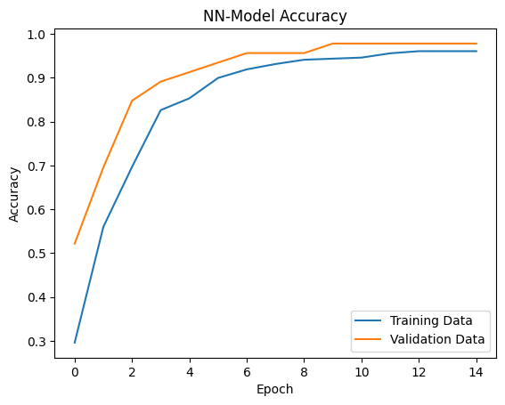

```python
plt.plot(history.history["accuracy"])
plt.plot(history.history["val_accuracy"])

plt.title("NN-Model Accuracy")
plt.ylabel("Accuracy")
plt.xlabel("Epoch")
plt.legend(["Training Data", "Validation Data"], loc="lower right")
plt.show()
```

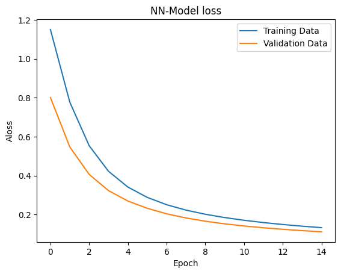

```python
plt.plot(history.history["loss"])
plt.plot(history.history["val_loss"])

plt.title("NN-Model loss")
plt.ylabel("Aloss")
plt.xlabel("Epoch")
plt.legend(["Training Data", "Validation Data"], loc="upper right")
plt.show()
```

#### Accuracy of the model on test data:

```python
loss, accuracy = model.evaluate(X_test_standard,Y_test)
print(accuracy)
```

```
4/4 ━━━━━━━━━━━━━━━━━━━━ 0s 6ms/step - accuracy: 0.9679 - loss: 0.1279
0.9561403393745422
```

#### To build a predictive system:

```python
print(X_test_standard.shape)
print(X_test_standard[0])
```

```
(114, 30)
[-0.04462793 -1.41612656 -0.05903514 -0.16234067  2.0202457  -0.11323672
  0.18500609  0.47102419  0.63336386  0.26335737  0.53209124  2.62763999
  0.62351167  0.11405261  1.01246781  0.41126289  0.63848593  2.88971815
 -0.41675911  0.74270853 -0.32983699 -1.67435595 -0.36854552 -0.38767294
  0.32655007 -0.74858917 -0.54689089 -0.18278004 -1.23064515 -0.6268286 ]
```

```python
Y_pred = model.predict(X_test_standard)
```

```
4/4 ━━━━━━━━━━━━━━━━━━━━ 0s 15ms/step
```

```python
print(Y_pred.shape)
print(Y_pred[0])
```

```
(114, 2)
[0.42705142 0.92283297]
```

- It will give that what is the probability of being 01st value) and 1(second value)

```python
print(X_test_standard)
```

```
[[-0.04462793 -1.41612656 -0.05903514 ... -0.18278004 -1.23064515
  -0.6268286 ]
 [ 0.24583601 -0.06219797  0.21802678 ...  0.54129749  0.11047691
   0.0483572 ]
 [-1.26115925 -0.29051645 -1.26499659 ... -1.35138617  0.269338
  -0.28231213]
 ...
 [ 0.72709489  0.45836817  0.75277276 ...  1.46701686  1.19909344
   0.65319961]
 [ 0.25437907  1.33054477  0.15659489 ... -1.29043534 -2.22561725
  -1.59557344]
 [ 0.84100232 -0.06676434  0.8929529  ...  2.15137705  0.35629355
   0.37459546]]
```

```python
print(Y_pred)
```

```
[[4.2705142e-01 9.2283297e-01]
 [4.3174511e-01 5.1621401e-01]
 [1.0326805e-01 9.8596209e-01]
 [9.6390522e-01 1.0503351e-02]
 [4.8384929e-01 5.7520914e-01]
 [8.2329249e-01 2.3955695e-02]
 [3.4244713e-01 8.9491105e-01]
 [1.0482406e-01 9.5468873e-01]
 [1.4288802e-01 9.0090024e-01]
 [1.5540709e-01 9.1644335e-01]
 [3.2109958e-01 3.1463629e-01]
 [3.5251030e-01 9.1423929e-01]
 [3.6236316e-01 9.7733831e-01]
 [3.4810159e-01 7.6429880e-01]
 [1.2072246e-01 9.6949053e-01]
 [5.0489819e-01 2.3501252e-01]
 [8.1106678e-02 9.7342467e-01]
 [2.6559016e-01 9.6240187e-01]
 [8.3701275e-02 9.6290016e-01]
 [8.7786013e-01 8.7682515e-02]
 [5.4841608e-01 9.9881876e-01]
 [1.0071574e-01 9.5781446e-01]
 [1.0159514e-01 9.5875525e-01]
 [1.3945055e-01 9.5619714e-01]
 [3.4090602e-01 8.3855391e-01]
 [6.8251002e-01 1.1147057e-01]
 [3.6263418e-01 8.1059730e-01]
 [3.5273635e-01 6.0439223e-01]
 [7.0097923e-01 1.0074188e-01]
 [6.3385993e-01 6.8996407e-02]
 [2.0393062e-01 8.6344266e-01]
 [1.8459381e-01 9.0987545e-01]
 [1.4214015e-01 9.2250472e-01]
 [8.4930128e-01 7.6358736e-04]
 [8.1985855e-01 8.0468766e-02]
 [1.7747226e-01 9.1120595e-01]
 [4.6033356e-02 9.5863414e-01]
 [2.1183203e-01 6.4111912e-01]
 [1.4647558e-01 9.8982608e-01]
 [3.1114992e-01 9.5384723e-01]
```

[output cut: 59 more lines]

```
 [5.7330634e-02 9.7493976e-01]
 [4.6759356e-02 9.8780847e-01]
 [8.6194247e-01 4.6094939e-01]
 [8.1912756e-01 8.8960333e-03]
 [9.0999943e-01 3.1738851e-02]
 [1.6423267e-01 8.1371605e-01]
 [1.9585170e-01 9.8076475e-01]
 [2.0041594e-01 9.9399579e-01]
 [4.2495039e-01 9.9347425e-01]
 [8.5987762e-02 9.9924612e-01]
 [2.5674531e-01 8.0285192e-01]
 [7.1918023e-01 4.2812090e-02]
 [8.0079526e-01 1.3098165e-02]
 [2.1914753e-01 7.6046652e-01]
 [7.2172058e-01 2.3393878e-01]]
```

model.predict() gives the prediction probability of each class for the data points

```python
# argmax fn
my_list = [10, 20, 30 ]
# find the index of max value
index_of_max = np.argmax(my_list)
print(my_list)
print(index_of_max)
```

```
[10, 20, 30]
2
```

```python
# converting the prediction probability to class label(0 or 1)

Y_pred_labels = [np.argmax(i) for i in Y_pred]
print(Y_pred_labels)
```

[output not shown]

#### Building the predictive system:

```python
input_data = tuple(df.iloc[1, :-1])

# Change the input data to a numpy array
input_data_as_numpy_array = np.asarray(input_data)

# reshape the numpyarray as we are predicting for 1 data point
input_data_reshape = input_data_as_numpy_array.reshape(1,-1)

# Standardize the input reshaped data
input_data_Standardize = scaler.transform(input_data_reshape)

# Prediction
prediction = model.predict(input_data_Standardize)

print(prediction)

prediction_label = [np.argmax(prediction)]
print(prediction_label)

if (prediction_label[0]  == 0):
    print("Malignant")
else:
    print("Benigin")
```

```
1/1 ━━━━━━━━━━━━━━━━━━━━ 0s 32ms/step
[[0.70097923 0.10074188]]
[0]
Malignant
```

```python
df.iloc[1,-1]
```

```
0
```